# convalescent plasma models

Natalya Kostandova

5/24/2020

# Model 1.

Assume the following compartmental model.

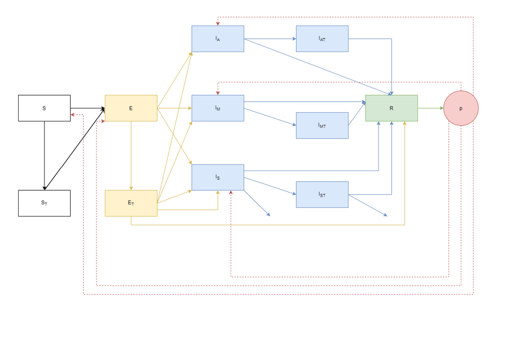

The $S$ compartment is susceptibles; here, we assume that it’s composed of general public and a healthcare workers compartment. The healthcare workers are assumed to have a higher number of contacts than the general public. $E$ is the exposed compartment. Infectious individuals are supposed to be split between $I_A$ (infectious asymptomatic), $I_M$ (infectious with mild symptoms), and $I_S$ (infectious with severe symptoms). $R$ is the recovered compartment. Plasma can be given to the susceptible population, in which case indivudals move to $S_T$ compartment; to exposed individuals as post-exposure prophylaxis (with individuals moving from $E$ to $E_T$ compartment), and to infectious people, who would then move to either $I_{AT}$, $I_{MT}$, or $I_{ST}$ compartment, depending on the compartment of origin. Note that because only a portion of plasma is “effective” (has a level of titer that’s high enough), some individuals will remain in the untreated compartment even if they received plasma.

We expect excess mortality due to COVID; it is assumed to only occur among severe cases ($I_S$). Excess mortality among infectious treated individuals with severe presentation is expected to be reduced.  
P represents the plasma compartments (number of units of plasma available at a given time).

## Population and Contact matrix

We assume population consisting of general public and health care workers. We assume increased contacts for healthcare workers.

Here, we use population structure for Washington DC, with age groups broken up in 0-19 years old, 20-44 years old, 45-54 years old, 55-74 years old, and 75 and greater years old. In addition, we have a healthcare worker compartment and a homeless compartment, with an estimated 6,000 healthcare workers. We set homeless compartment to 1 for the purposes of this simulation (essentially 0).

The contact matrix used is from Polymod for UK; contacts for healthcare workers and individuals experiencing homelessness are assumed to be the same as for the 45-54 year old category.

## Set up the SEAIR model

Initial conditions and assumptions are as follows:

-Everybody in the population is susceptible  
-15 people infected in general population (1 in each compartment for asymptomatic, mild, and severe); 0 in healthcare workers  
-R0 = 2.5  
-$\gamma$ = recovery rate = 1 / (6.5days)  
-$\sigma$ = 1 / (5.2 days)  
-natural death rate = 0  
-birth rate = 0  
-mortality rate from infection = probability of death among hospitalized / (3*7), where 3 weeks = median number of days from symptoms to death

For plasma, we assume -proportion of plasma that’s functional (with high enough titer) is 70%  
-Among those susceptibles that receive functional plasma, transmission coefficient is reduced by 50%  
-$\gamma_t$ = 1 / 4 (duration of time to recovery is reduced from 6.5 days to 4 days)  
-mortality rate from infection for treated individuals is = (half of mortality for untreated people)  
-proportion of exposed individuals treated with effective plasma that move on to infected compartment is $prop_{ETI}$ = 0.1

We set the following parameters:  
-p0 = number of units of plasma available at day 1 (default, 2000) -$p_{use}$ = proportion of plasma available to be used (for example, not diverted towards hyperimmune globulin)  
-$p_s$ = proportion of plasma allocated to be administered to susceptible individuals  
-$p_e$ = proportion of plasma allocated to be administered to exposed individuals  
-$p_ia$ = proportion of plasma allocated to be administered to infected individuals (asymptomatic)  
-$p_im$ = proportion of plasma allocated to be administered to infected individuals (mild)  
-$p_is$ = proportion of plasma allocated to be administered to infected individuals (severe)  
-$rate_p$ = rate at which plasma is donated; assumed to be 3.5 units / 14 days (assuming each person that donates gives 3.5 units)  
-$p_{give}$ = proportion of recovered individuals that give plasma (default: 0.1)

We assume that all individuals in exposed compartment will move to either asymptomatic, mild, or severe compartments. We assume that there is no excess death from COVID-19 in either asymptomatic or mild individuals. Probability of becoming symptomatic and progressing to severe disease is based on CDC data, assuming 2% mortality [CDC](https://www.cdc.gov/mmwr/volumes/69/wr/mm6912e2.htm#T1_down).

We assume rates of recovery to be the same from the three levels of different severity.

## Scenarios

Scenario 1: no plasma is administered

```
## Using POLYMOD social contact data. To cite this in a publication, use the 'cite' function
```

```
## Removing participants that have contacts without age information. To change this behaviour, set the 'missing.contact.age' option
```

Run single simulations - deterministic and stochastic

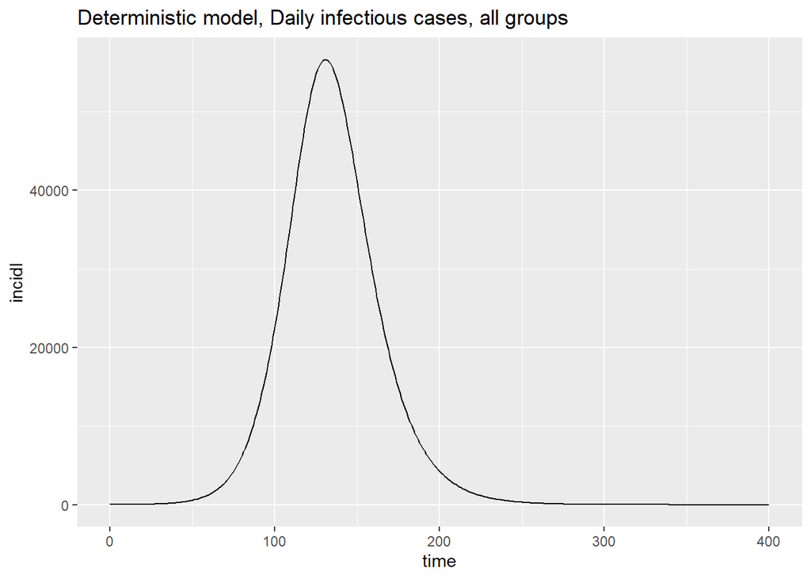

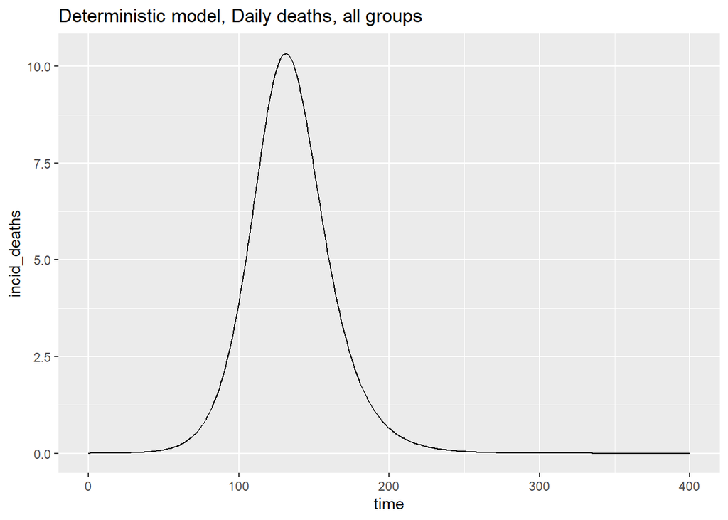

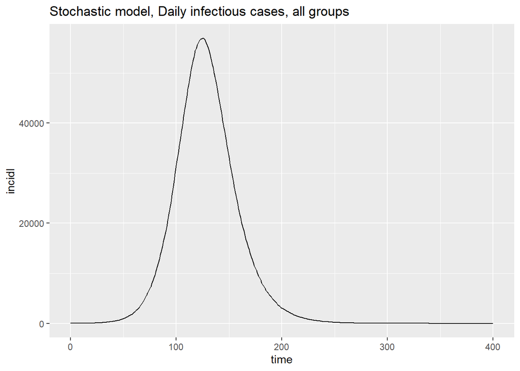

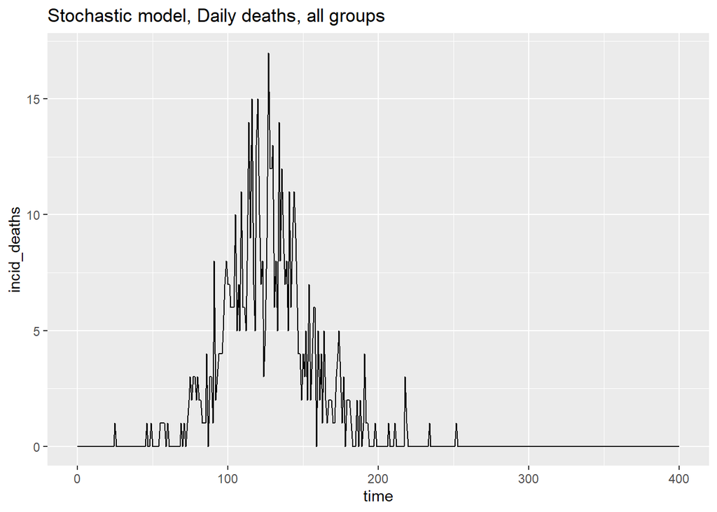

Now run multiple simulations for the stochastic formulation

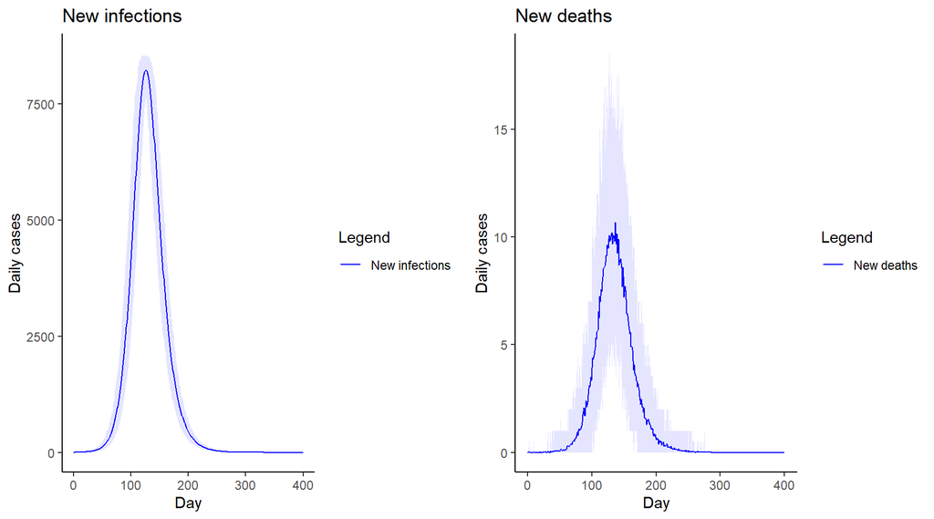

|  | Final infection size | Final deaths from COVID |
| --- | --- | --- |
| Mean | 513616 | 635 |
| Median | 513584 | 636 |
| lower 95% CI limit | 512097 | 589 |
| upper 95% CI limit | 515138 | 683 |

Scenario 2 - assume we are only treating individuals in I severe; (100% of available plasma goes to severe infectious people - 0.1 in each of first 2 groups, 0.2 in last 3 groups, and 0.2 to healthcare workers)

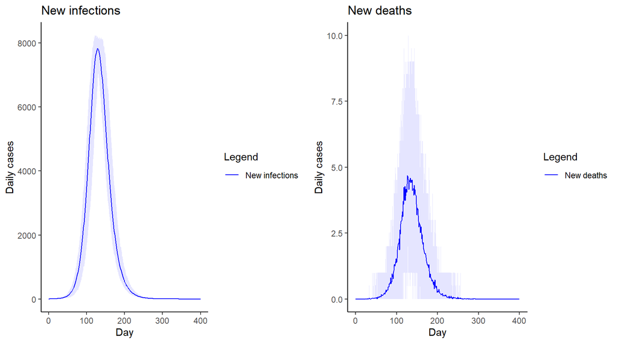

Scenario 3 - assume we are only giving plasma only to susceptible healthworkers (2,000 units of plasma available at t=0)

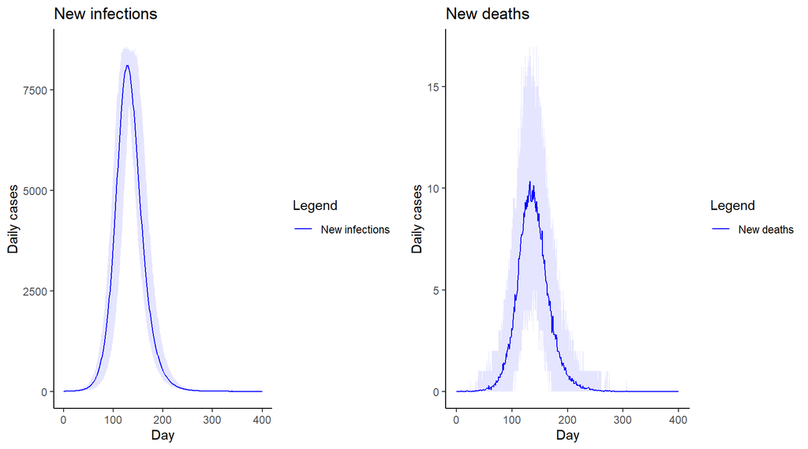

|  | Scenario 1 Final infection size | Scenario 1 Final deaths from COVID | Scenario 1 Number receiving plasma | Scenario 2 Final infection size | Scenario 2 Final deaths from COVID | Scenario 2 Number receiving plasma | Scenario 3 Final infection size | Scenario 3 Final deaths from COVID | Scenario 3 Number receiving plasma |
| --- | --- | --- | --- | --- | --- | --- | --- | --- | --- |
| Mean | 513616 | 635 | 0 | 502738 | 288 | 63154 | 513690 | 632 | 4733 |
| Median | 513584 | 636 | 0 | 502759 | 288 | 63154 | 513658 | 632 | 4736 |
| lower 95% CI limit | 512097 | 589 | 0 | 501220 | 256 | 62713 | 512206 | 582 | 4643 |
| upper 95% CI limit | 515138 | 683 | 0 | 504155 | 322 | 63618 | 515144 | 678 | 4809 |

Note:  
Scenario 1 = no plasma intervention; Scenario 2 = plasma treatment to infectious compartment only; Scenario 3 = plasma treatment to susceptible health workers only

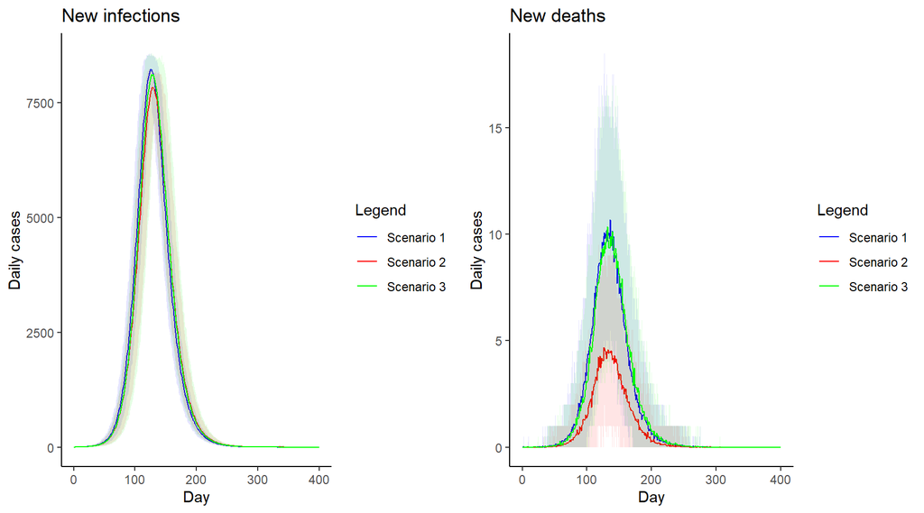

Alternative scenario —- all sorts of infected folks (including asymptomatic and mild), 2,000 units of plasma available

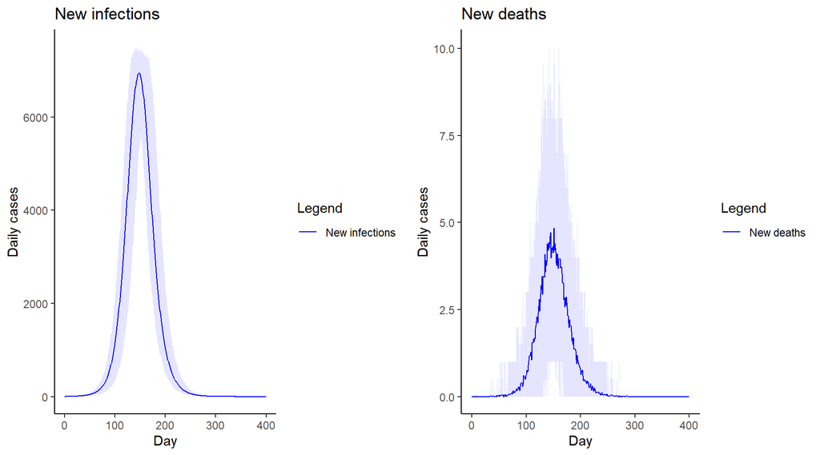

|  | Final infection size | Final deaths from COVID |
| --- | --- | --- |
| Mean | 444728 | 287 |
| Median | 444637 | 288 |
| lower 95% CI limit | 442372 | 256 |
| upper 95% CI limit | 447239 | 324 |

Alternative scenario 3 —- lots of plasma to susceptibles

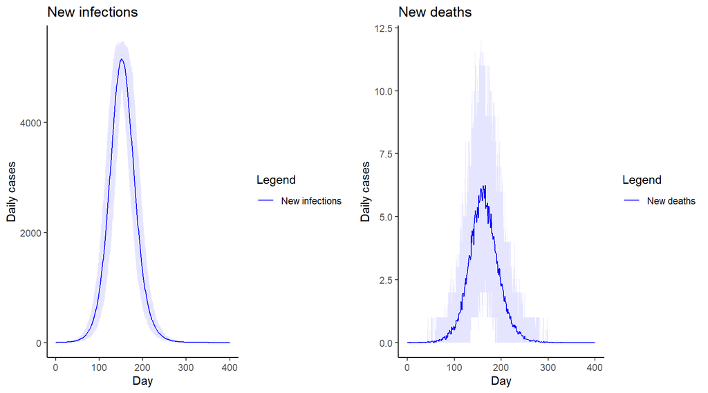

|  | Final infection size | Final deaths from COVID |
| --- | --- | --- |
| Mean | 368033 | 428 |
| Median | 367830 | 428 |
| lower 95% CI limit | 365617 | 390 |
| upper 95% CI limit | 370861 | 470 |

Alternative scenario —- lots of plasma to infected (200,000 units available at t=0, proportion of plasma assigned to severely infected: 0.1, 0.2, 0.2, 0.2, 0.2, 0.1 to each compartment, respectively)

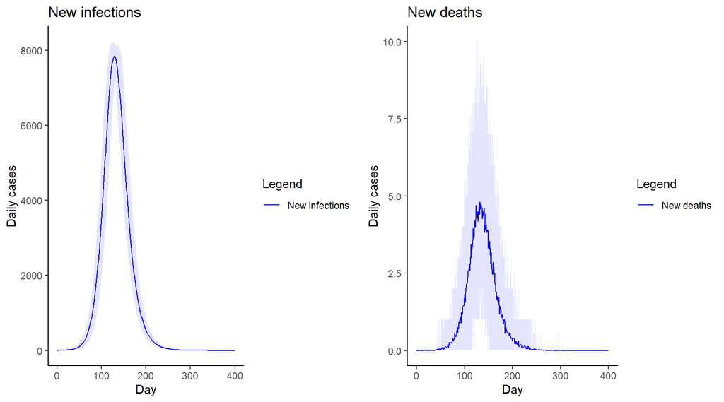

|  | Final infection size | Final deaths from COVID |
| --- | --- | --- |
| Mean | 502615 | 292 |
| Median | 502676 | 290 |
| lower 95% CI limit | 501247 | 261 |
| upper 95% CI limit | 503803 | 323 |

Alternative scenario —- plasma to exposed only (2,000 units available at t=0, proportion of plasma assigned to exposed: 0.1, 0.1, 0.2, 0.2, 0.2, 0.2 to each compartment, respectively)

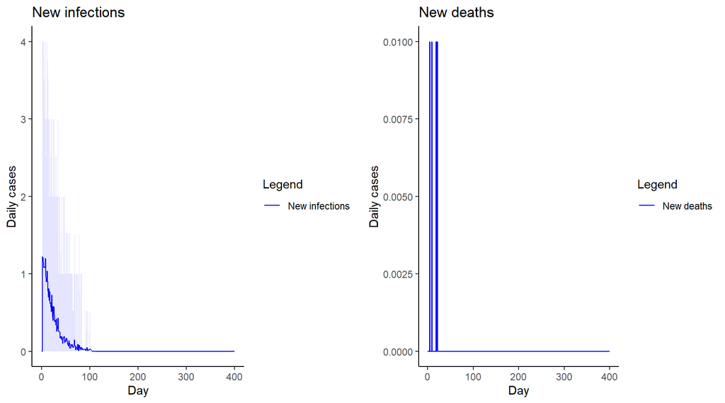

|  | Final infection size | Final deaths from COVID |
| --- | --- | --- |
| Mean | 29 | 0 |
| Median | 26 | 0 |
| lower 95% CI limit | 7 | 0 |
| upper 95% CI limit | 74 | 1 |